# Practical Machine Learning Project for Weight Lifting Exercise Dataset

Terence Lim Zheng Wei

26 January 2016

## Background

Using devices such as Jawbone Up, Nike FuelBand, and Fitbit it is now possible to collect a large amount of data about personal activity relatively inexpensively. These type of devices are part of the quantified self movement - a group of enthusiasts who take measurements about themselves regularly to improve their health, to find patterns in their behavior, or because they are tech geeks. One thing that people regularly do is quantify how much of a particular activity they do, but they rarely quantify how well they do it. In this project, your goal will be to use data from accelerometers on the belt, forearm, arm, and dumbell of 6 participants. They were asked to perform barbell lifts correctly and incorrectly in 5 different ways. More information is available from the website here: http://groupware.les.inf.puc-rio.br/har (see the section on the Weight Lifting Exercise Dataset).

The training data for this project are available here:

https://d396qusza40orc.cloudfront.net/predmachlearn/pml-training.csv

The test data are available here:

https://d396qusza40orc.cloudfront.net/predmachlearn/pml-testing.csv

## Load Dataset

This section downloads the dataset and stores them into two dataframes, training and testing.

```r
library(caret)
library(ggplot2)
library(dplyr)
set.seed(333)

filenames <- c("pml-training.csv","pml-testing.csv")

if(sum(list.files() %in% filenames)==0){
    download.file("https://d396qusza40orc.cloudfront.net/predmachlearn/
                  pml-training.csv","pml-training.csv")
    download.file("https://d396qusza40orc.cloudfront.net/predmachlearn/
                  pml-testing.csv","pml-testing.csv")
}

training <- tbl_df(read.csv("pml-training.csv",header=TRUE,na.strings=c("NA","")))
testing <- tbl_df(read.csv("pml-testing.csv",header=TRUE,na.strings=c("NA","")))
names(training)
```

```
##   [1] "X"                        "user_name"
##   [3] "raw_timestamp_part_1"     "raw_timestamp_part_2"
##   [5] "cvtd_timestamp"           "new_window"
##   [7] "num_window"               "roll_belt"
##   [9] "pitch_belt"               "yaw_belt"
##  [11] "total_accel_belt"         "kurtosis_roll_belt"
##  [13] "kurtosis_picth_belt"      "kurtosis_yaw_belt"
##  [15] "skewness_roll_belt"       "skewness_roll_belt.1"
##  [17] "skewness_yaw_belt"        "max_roll_belt"
##  [19] "max_picth_belt"           "max_yaw_belt"
##  [21] "min_roll_belt"            "min_pitch_belt"
##  [23] "min_yaw_belt"             "amplitude_roll_belt"
##  [25] "amplitude_pitch_belt"     "amplitude_yaw_belt"
##  [27] "var_total_accel_belt"     "avg_roll_belt"
##  [29] "stddev_roll_belt"         "var_roll_belt"
```

[output cut: 65 more lines]

We will be using the data available to predict the classe variable.

## Pre-process data

Remove first 7 columns of data as they do not assist in predicting classe based on physical movements

```r
training<-training[,-c(1:7)]
testing<-testing[,-c(1:7)]
```

Remove columns which have greater than 80% of N.A values

```r
num_na <- colSums(is.na(training))
low_na_col <- num_na < 0.8 * nrow(training)
training <- training[,low_na_col]
testing <- testing[,low_na_col]
```

Check whether there are columns with near zero variance as they do not assist in prediction

```r
nsv <- nearZeroVar(training,saveMetrics = TRUE)
nsv
```

```
##                      freqRatio percentUnique zeroVar   nzv
## roll_belt             1.101904     6.7781062   FALSE FALSE
## pitch_belt            1.036082     9.3772296   FALSE FALSE
## yaw_belt              1.058480     9.9734991   FALSE FALSE
## total_accel_belt      1.063160     0.1477933   FALSE FALSE
## gyros_belt_x          1.058651     0.7134849   FALSE FALSE
## gyros_belt_y          1.144000     0.3516461   FALSE FALSE
## gyros_belt_z          1.066214     0.8612782   FALSE FALSE
## accel_belt_x          1.055412     0.8357966   FALSE FALSE
## accel_belt_y          1.113725     0.7287738   FALSE FALSE
## accel_belt_z          1.078767     1.5237998   FALSE FALSE
## magnet_belt_x         1.090141     1.6664968   FALSE FALSE
## magnet_belt_y         1.099688     1.5187035   FALSE FALSE
## magnet_belt_z         1.006369     2.3290184   FALSE FALSE
## roll_arm             52.338462    13.5256345   FALSE FALSE
## pitch_arm            87.256410    15.7323412   FALSE FALSE
## yaw_arm              33.029126    14.6570176   FALSE FALSE
## total_accel_arm       1.024526     0.3363572   FALSE FALSE
## gyros_arm_x           1.015504     3.2769341   FALSE FALSE
## gyros_arm_y           1.454369     1.9162165   FALSE FALSE
## gyros_arm_z           1.110687     1.2638875   FALSE FALSE
## accel_arm_x           1.017341     3.9598410   FALSE FALSE
## accel_arm_y           1.140187     2.7367241   FALSE FALSE
## accel_arm_z           1.128000     4.0362858   FALSE FALSE
## magnet_arm_x          1.000000     6.8239731   FALSE FALSE
## magnet_arm_y          1.056818     4.4439914   FALSE FALSE
## magnet_arm_z          1.036364     6.4468454   FALSE FALSE
## roll_dumbbell         1.022388    84.2065029   FALSE FALSE
## pitch_dumbbell        2.277372    81.7449801   FALSE FALSE
## yaw_dumbbell          1.132231    83.4828254   FALSE FALSE
## total_accel_dumbbell  1.072634     0.2191418   FALSE FALSE
## gyros_dumbbell_x      1.003268     1.2282132   FALSE FALSE
## gyros_dumbbell_y      1.264957     1.4167771   FALSE FALSE
## gyros_dumbbell_z      1.060100     1.0498420   FALSE FALSE
## accel_dumbbell_x      1.018018     2.1659362   FALSE FALSE
## accel_dumbbell_y      1.053061     2.3748853   FALSE FALSE
## accel_dumbbell_z      1.133333     2.0894914   FALSE FALSE
## magnet_dumbbell_x     1.098266     5.7486495   FALSE FALSE
## magnet_dumbbell_y     1.197740     4.3012945   FALSE FALSE
## magnet_dumbbell_z     1.020833     3.4451126   FALSE FALSE
## roll_forearm         11.589286    11.0895933   FALSE FALSE
## pitch_forearm        65.983051    14.8557741   FALSE FALSE
## yaw_forearm          15.322835    10.1467740   FALSE FALSE
## total_accel_forearm   1.128928     0.3567424   FALSE FALSE
## gyros_forearm_x       1.059273     1.5187035   FALSE FALSE
## gyros_forearm_y       1.036554     3.7763735   FALSE FALSE
## gyros_forearm_z       1.122917     1.5645704   FALSE FALSE
## accel_forearm_x       1.126437     4.0464784   FALSE FALSE
## accel_forearm_y       1.059406     5.1116094   FALSE FALSE
## accel_forearm_z       1.006250     2.9558659   FALSE FALSE
## magnet_forearm_x      1.012346     7.7667924   FALSE FALSE
## magnet_forearm_y      1.246914     9.5403119   FALSE FALSE
## magnet_forearm_z      1.000000     8.5771073   FALSE FALSE
## classe                1.469581     0.0254816   FALSE FALSE
```

## Prediction

Split the dataset into the training set and cross validation set.

```r
inTrain <- createDataPartition(training$classe,p=0.6,list=FALSE)
train_data <- training[inTrain,]
cv_data <- training[-inTrain,]
```

Set the training controls to use 3 fold cross validation

```r
fitControl <- trainControl(method="cv", number=3, verboseIter=F)
```

Use a CART Model for prediction. This model results in low accuracy and thus we will use random forests to see whether it improves performance.

```r
tree_fit <- train(classe~.,method="rpart",data=train_data,
                  trControl = fitControl)
tree_pred <- predict(tree_fit,cv_data)
confusionMatrix(tree_pred,cv_data$classe)$overall
```

```
##       Accuracy          Kappa  AccuracyLower  AccuracyUpper   AccuracyNull
##      0.4977058      0.3430350      0.4865813      0.5088321      0.2844762
## AccuracyPValue  McnemarPValue
##      0.0000000            NaN
```

Use a Random Forest Model for prediction. This model achieves high accuracy when predicted against the cross validation set. We will use this model to predict against the testing dataset.

```r
tree_fit <- train(classe~.,method="rf",data=train_data,
                  trControl = fitControl, allowParallel=TRUE)
tree_pred <- predict(tree_fit,cv_data)
confusionMatrix(tree_pred,cv_data$classe)$overall
```

```
##       Accuracy          Kappa  AccuracyLower  AccuracyUpper   AccuracyNull
##      0.9931175      0.9912929      0.9910293      0.9948256      0.2844762
## AccuracyPValue  McnemarPValue
##      0.0000000            NaN
```

Using the random forest model against the cross validation set, the out of sample error is `0.0068825`

## Variable Importance

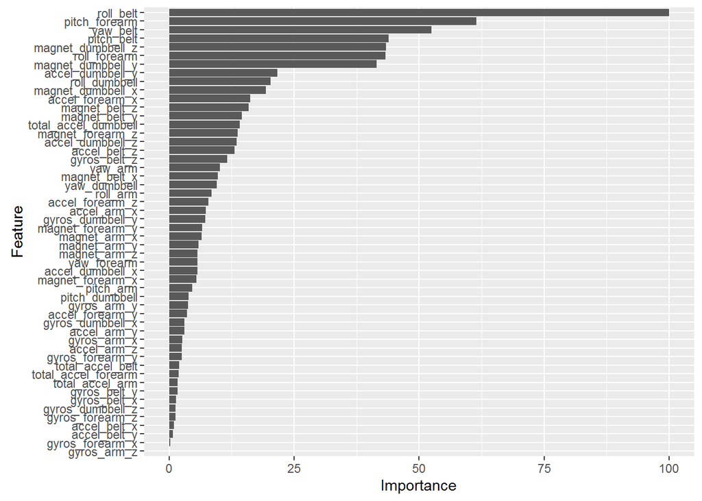

```r
ggplot(varImp(tree_fit),aes(y=importance))+geom_bar(stat="identity")
```

From this we can see the relative importance of variable used in deriving the model. For computational sake, this can be used for dimensionality reduction to decide which variables to use in the model.

## Prediction on Test Set

```r
test_pred <- predict(tree_fit,testing[,-53])
test_pred
```

```
##  [1] B A B A A E D B A A B C B A E E A B B B
## Levels: A B C D E
```